# Coverage Analysis: Entamoeba histolytica knockout libraries

Sam Hunter

11 May, 2020

## Results for forward-read coverage counts:

### Summary statistics for all samples:

|  | Sample | reads | AssignedReads | CoveredGenes | Fragmented.gDNA | Group | Type | Rep | PCR.Cycles |
| --- | --- | --- | --- | --- | --- | --- | --- | --- | --- |
| B1.FA.bam | B1.FA | 320901 | 68717 | 8140 | FA | Pilot | gDNA | 1 | 5 |
| B2.FA.bam | B2.FA | 340395 | 73224 | 8170 | FA | Pilot | gDNA | 2 | 5 |
| B3.FA.bam | B3.FA | 240107 | 55003 | 7987 | FA | Pilot | gDNA | 3 | 5 |
| gLibA.A5.bam | gLibA.A5 | 180884 | 50297 | 173 | FA | Pilot | Plasmid | 1 | 5 |
| gLibA.A6.bam | gLibA.A6 | 264725 | 72247 | 172 | FA | Pilot | Plasmid | 2 | 5 |
| gLibA.A7.bam | gLibA.A7 | 384836 | 100330 | 172 | FA | Pilot | Plasmid | 3 | 5 |
| D10.FB.1.bam | D10.FB.1 | 881505 | 207082 | 8299 | FB | Final | gDNA | 1 | 5 |
| D11.FB.2.bam | D11.FB.2 | 692763 | 161970 | 8295 | FB | Final | gDNA | 2 | 5 |
| D12.FB.3.bam | D12.FB.3 | 976855 | 229529 | 8305 | FB | Final | gDNA | 3 | 5 |
| F1.LibB1.1.bam | F1.LibB1.1 | 972753 | 277801 | 7767 | FB | Final | Plasmid | 1 | 5 |
| F2.LibB1.2.bam | F2.LibB1.2 | 853610 | 240547 | 7759 | FB | Final | Plasmid | 2 | 5 |
| F3.LibB1.3.bam | F3.LibB1.3 | 976763 | 275783 | 7783 | FB | Final | Plasmid | 3 | 5 |
| F4.LibB2.1.bam | F4.LibB2.1 | 950822 | 282794 | 8067 | FB | Final | Plasmid | 1 | 5 |
| F5.LibB2.2.bam | F5.LibB2.2 | 1123212 | 331428 | 8111 | FB | Final | Plasmid | 2 | 5 |
| F6.LibB2.3.bam | F6.LibB2.3 | 1147730 | 336278 | 8099 | FB | Final | Plasmid | 3 | 5 |
| F7.LibB3.1.bam | F7.LibB3.1 | 992325 | 291167 | 8094 | FB | Final | Plasmid | 1 | 5 |
| F8.LibB3.2.bam | F8.LibB3.2 | 1828332 | 535994 | 8172 | FB | Final | Plasmid | 2 | 5 |
| F9.LibB3.3.bam | F9.LibB3.3 | 1514682 | 440111 | 8135 | FB | Final | Plasmid | 3 | 5 |
| F10.LibB4.1.bam | F10.LibB4.1 | 1524301 | 331059 | 6549 | FB | Final | Plasmid | 1 | 5 |
| F11.LibB4.2.bam | F11.LibB4.2 | 1343977 | 298159 | 6472 | FB | Final | Plasmid | 2 | 5 |
| F12.LibB4.3.bam | F12.LibB4.3 | 2165943 | 483546 | 6739 | FB | Final | Plasmid | 3 | 5 |

### How does gene coverage correspond to sequencing depth?

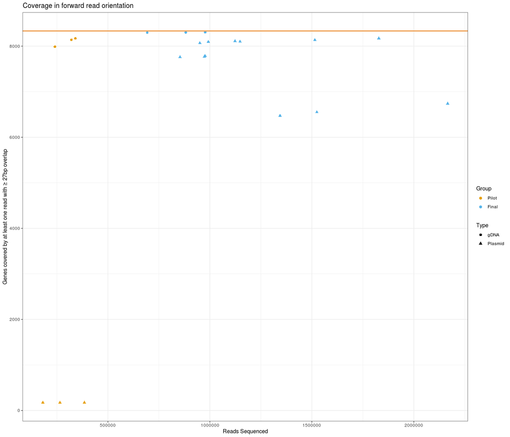

What is the distribution of number of reads mapped per gene?

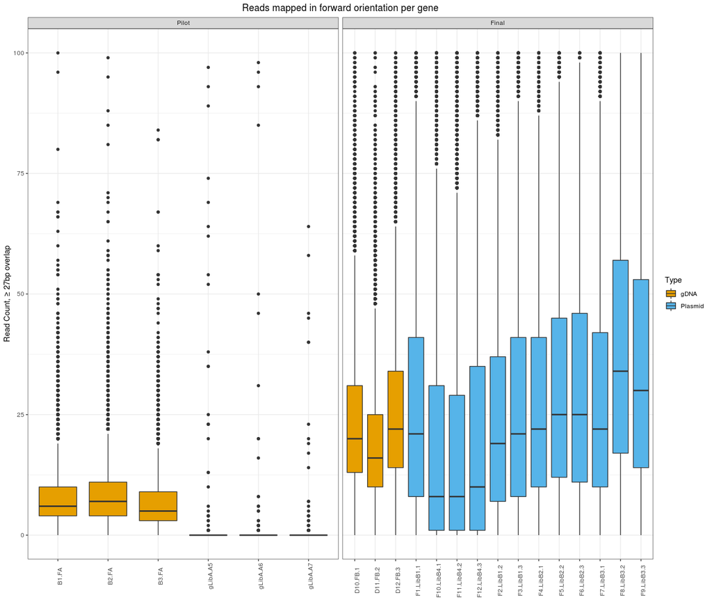

What is read coverage like across all genes, and do samples cluster by prep?

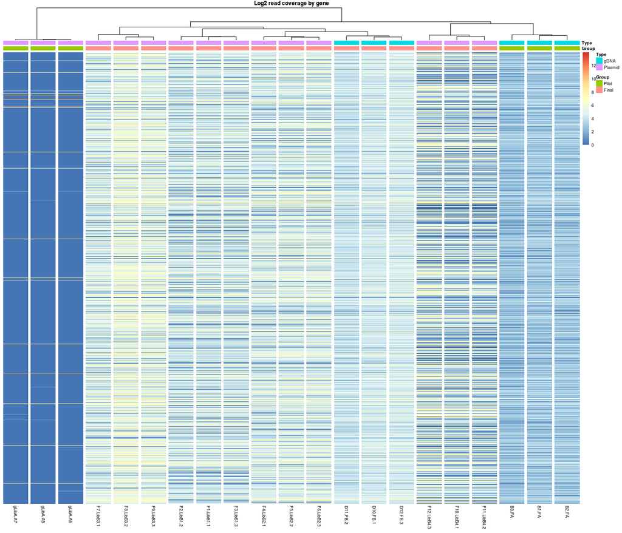

What is read coverage like across all genes for Final samples only? Do samples cluster by prep?

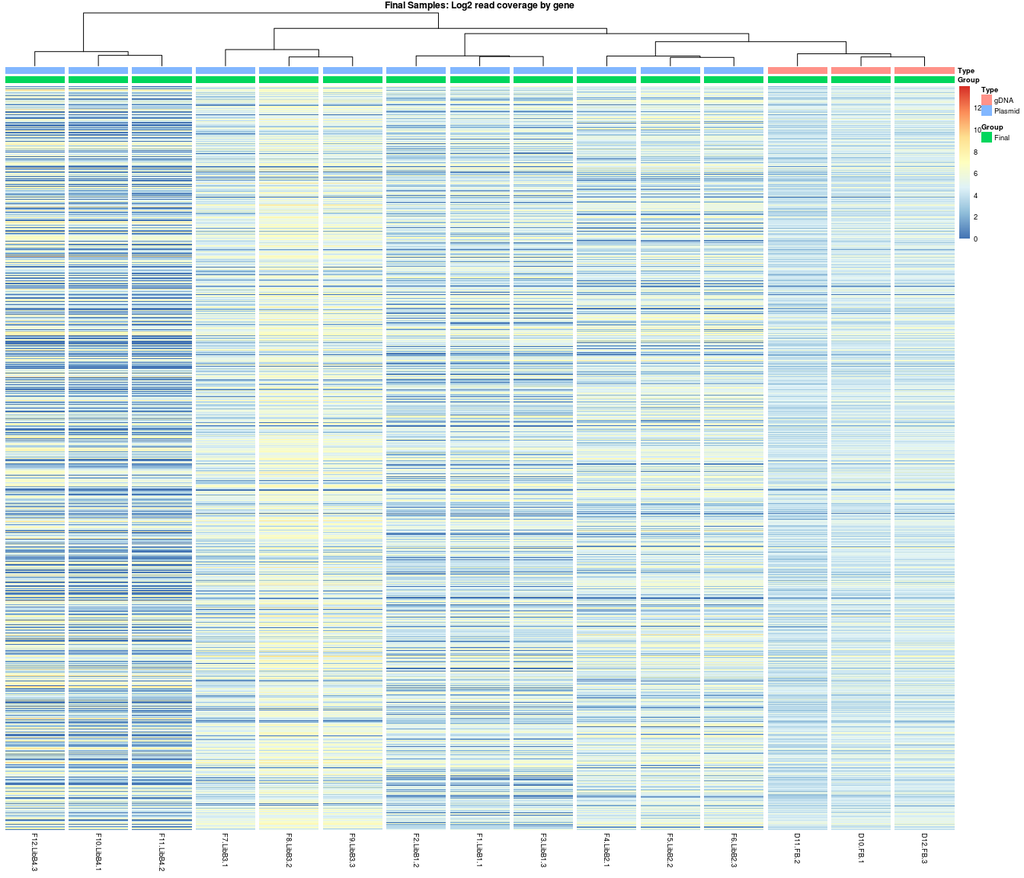

Are any genes not covered in most/all samples?

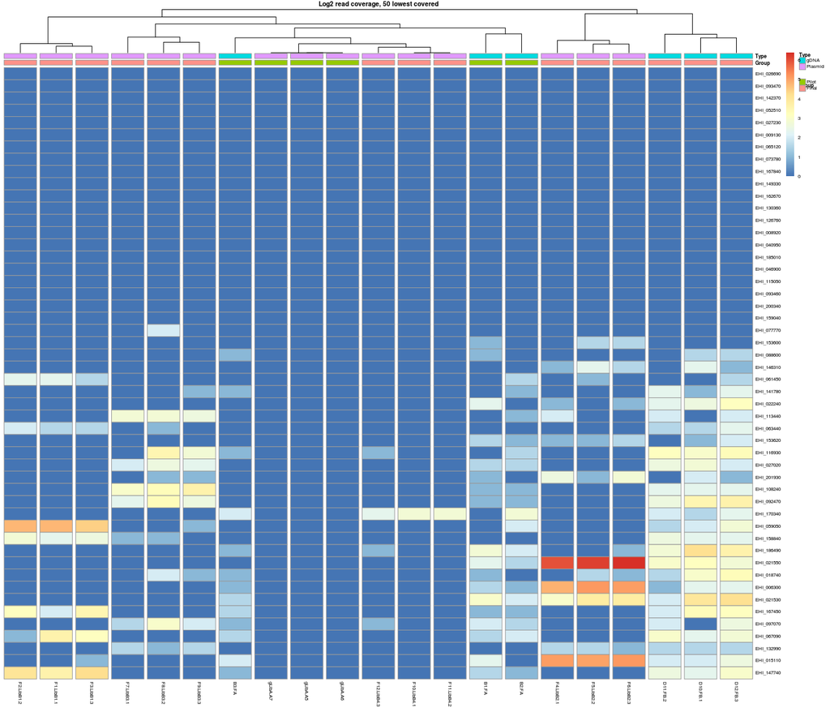

Are any genes not covered in samples from the Final group?

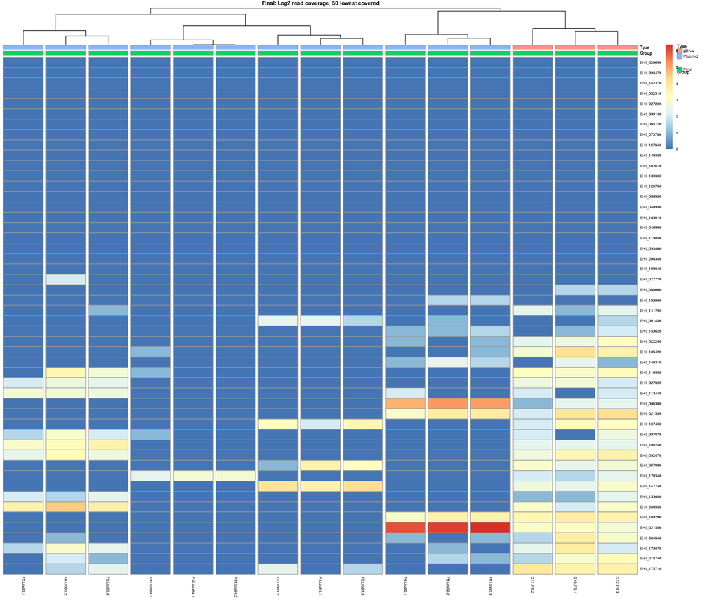

Final: Are any genes not covered in most/all Final samples after pooling?

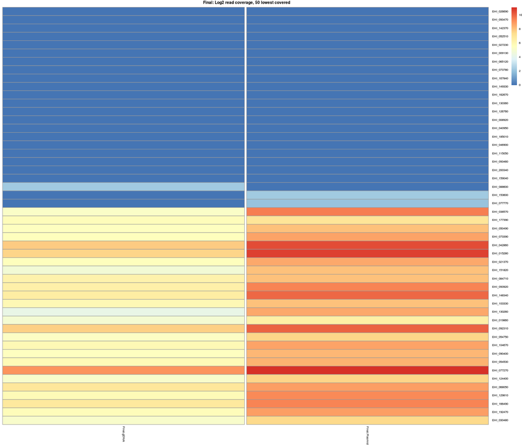

Final: Are any genes not covered in most/all Final samples after pooling?

|  | Final.gDNA | Final.Plasmid |
| --- | --- | --- |
| EHI_026690 | 0 | 0 |
| EHI_093470 | 0 | 0 |
| EHI_142370 | 0 | 0 |
| EHI_052510 | 0 | 0 |
| EHI_027230 | 0 | 0 |
| EHI_009130 | 0 | 0 |
| EHI_065120 | 0 | 0 |
| EHI_073780 | 0 | 0 |
| EHI_167840 | 0 | 0 |
| EHI_149330 | 0 | 0 |
| EHI_162670 | 0 | 0 |
| EHI_130360 | 0 | 0 |
| EHI_126760 | 0 | 0 |
| EHI_008920 | 0 | 0 |
| EHI_040950 | 0 | 0 |
| EHI_185010 | 0 | 0 |
| EHI_046900 | 0 | 0 |
| EHI_115050 | 0 | 0 |
| EHI_093460 | 0 | 0 |
| EHI_200340 | 0 | 0 |
| EHI_159040 | 0 | 0 |
| EHI_088600 | 4 | 0 |
| EHI_153600 | 0 | 4 |
| EHI_077770 | 0 | 3 |
| EHI_038570 | 38 | 709 |
| EHI_177390 | 52 | 134 |
| EHI_050490 | 43 | 270 |
| EHI_073390 | 49 | 426 |
| EHI_042860 | 231 | 1473 |
| EHI_015280 | 191 | 1679 |
| EHI_021370 | 49 | 397 |
| EHI_151820 | 28 | 266 |
| EHI_084710 | 78 | 258 |
| EHI_093920 | 80 | 681 |
| EHI_148340 | 100 | 1013 |
| EHI_103330 | 61 | 260 |
| EHI_130260 | 19 | 385 |
| EHI_019860 | 30 | 90 |
| EHI_092310 | 205 | 1070 |
| EHI_054750 | 40 | 194 |
| EHI_104670 | 61 | 422 |
| EHI_090400 | 45 | 318 |
| EHI_054530 | 56 | 327 |
| EHI_077270 | 518 | 2193 |
| EHI_124400 | 35 | 200 |
| EHI_068050 | 118 | 466 |
| EHI_129810 | 58 | 605 |
| EHI_166490 | 109 | 662 |
| EHI_192470 | 51 | 449 |
| EHI_030480 | 36 | 181 |

## Results for reverse-read coverage counts:

### Summary statistics for all samples:

|  | Sample | reads | AssignedReads | CoveredGenes | Fragmented.gDNA | Group | Type | Rep | PCR.Cycles |
| --- | --- | --- | --- | --- | --- | --- | --- | --- | --- |
| B1.FA.bam | B1.FA | 320901 | 70071 | 8153 | FA | Pilot | gDNA | 1 | 5 |
| B2.FA.bam | B2.FA | 340395 | 75410 | 8199 | FA | Pilot | gDNA | 2 | 5 |
| B3.FA.bam | B3.FA | 240107 | 56501 | 8021 | FA | Pilot | gDNA | 3 | 5 |
| gLibA.A5.bam | gLibA.A5 | 180884 | 46853 | 174 | FA | Pilot | Plasmid | 1 | 5 |
| gLibA.A6.bam | gLibA.A6 | 264725 | 68694 | 176 | FA | Pilot | Plasmid | 2 | 5 |
| gLibA.A7.bam | gLibA.A7 | 384836 | 95468 | 183 | FA | Pilot | Plasmid | 3 | 5 |
| D10.FB.1.bam | D10.FB.1 | 881505 | 210038 | 8300 | FB | Final | gDNA | 1 | 5 |
| D11.FB.2.bam | D11.FB.2 | 692763 | 165333 | 8292 | FB | Final | gDNA | 2 | 5 |
| D12.FB.3.bam | D12.FB.3 | 976855 | 234844 | 8298 | FB | Final | gDNA | 3 | 5 |
| F1.LibB1.1.bam | F1.LibB1.1 | 972753 | 273129 | 7794 | FB | Final | Plasmid | 1 | 5 |
| F2.LibB1.2.bam | F2.LibB1.2 | 853610 | 236261 | 7780 | FB | Final | Plasmid | 2 | 5 |
| F3.LibB1.3.bam | F3.LibB1.3 | 976763 | 270950 | 7796 | FB | Final | Plasmid | 3 | 5 |
| F4.LibB2.1.bam | F4.LibB2.1 | 950822 | 276166 | 8065 | FB | Final | Plasmid | 1 | 5 |
| F5.LibB2.2.bam | F5.LibB2.2 | 1123212 | 324550 | 8100 | FB | Final | Plasmid | 2 | 5 |
| F6.LibB2.3.bam | F6.LibB2.3 | 1147730 | 329212 | 8094 | FB | Final | Plasmid | 3 | 5 |
| F7.LibB3.1.bam | F7.LibB3.1 | 992325 | 293918 | 8096 | FB | Final | Plasmid | 1 | 5 |
| F8.LibB3.2.bam | F8.LibB3.2 | 1828332 | 541336 | 8176 | FB | Final | Plasmid | 2 | 5 |
| F9.LibB3.3.bam | F9.LibB3.3 | 1514682 | 445601 | 8149 | FB | Final | Plasmid | 3 | 5 |
| F10.LibB4.1.bam | F10.LibB4.1 | 1524301 | 337594 | 6576 | FB | Final | Plasmid | 1 | 5 |
| F11.LibB4.2.bam | F11.LibB4.2 | 1343977 | 304776 | 6559 | FB | Final | Plasmid | 2 | 5 |
| F12.LibB4.3.bam | F12.LibB4.3 | 2165943 | 492896 | 6757 | FB | Final | Plasmid | 3 | 5 |

### How does gene coverage correspond to sequencing depth?

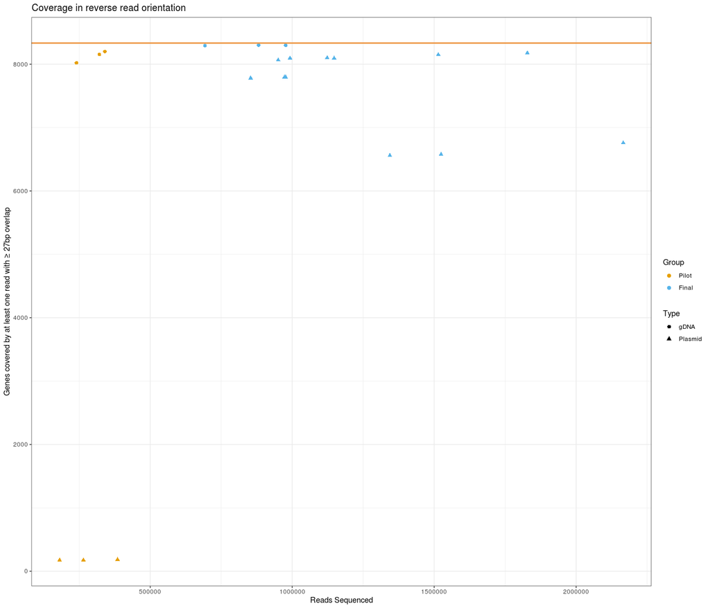

What is the distribution of number of reads mapped per gene?

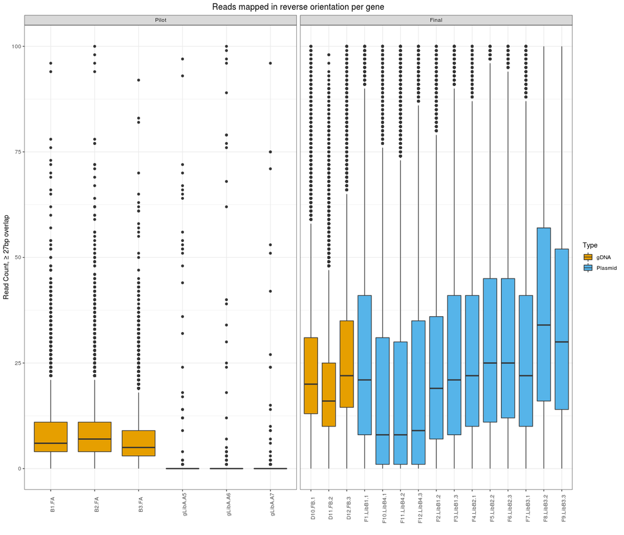

What is read coverage like across all genes, and do samples cluster by prep?

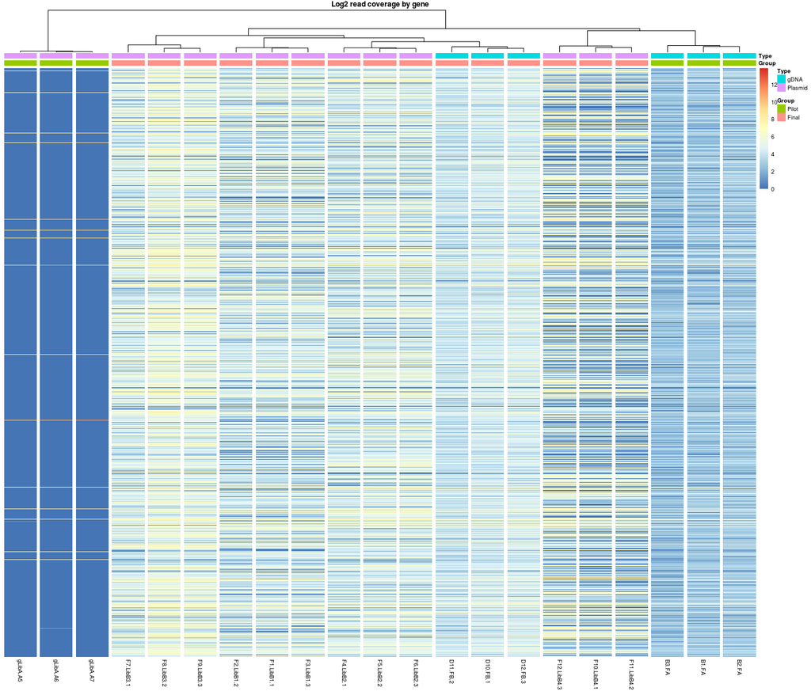

What is read coverage like across all genes for Final samples only? Do samples cluster by prep?

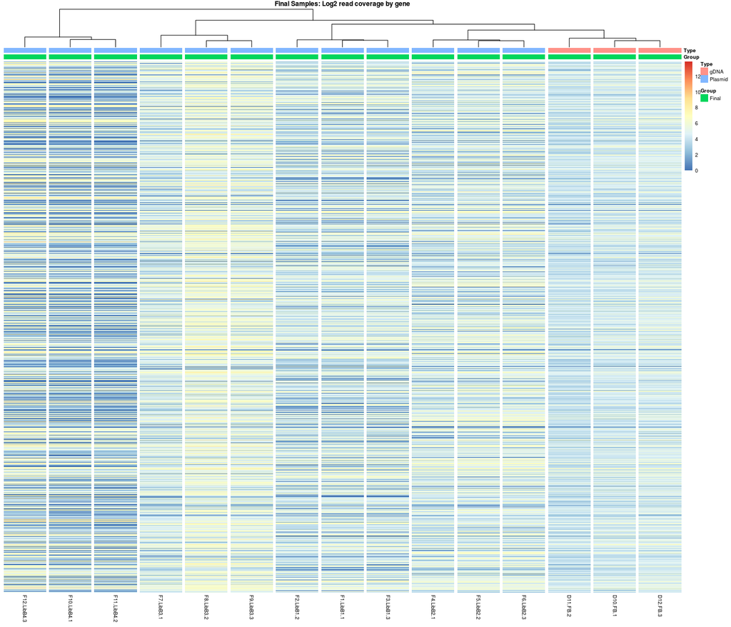

Are any genes not covered in most/all samples?

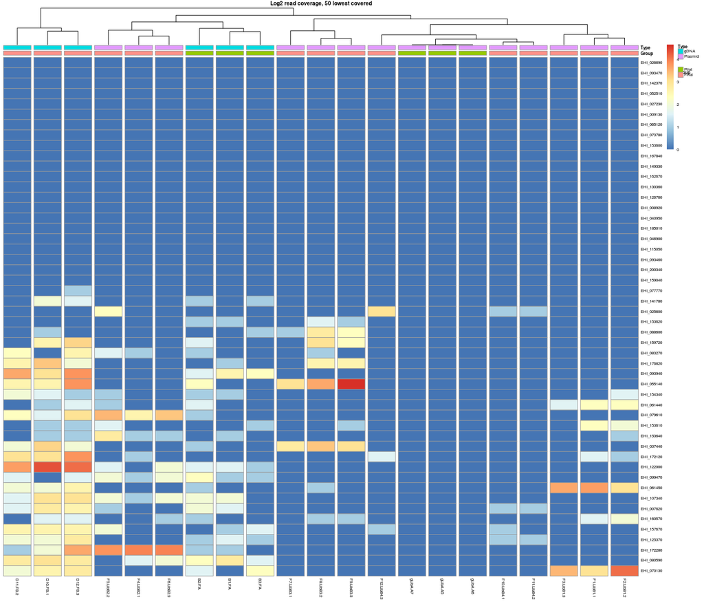

Are any genes not covered in samples from the Final group?

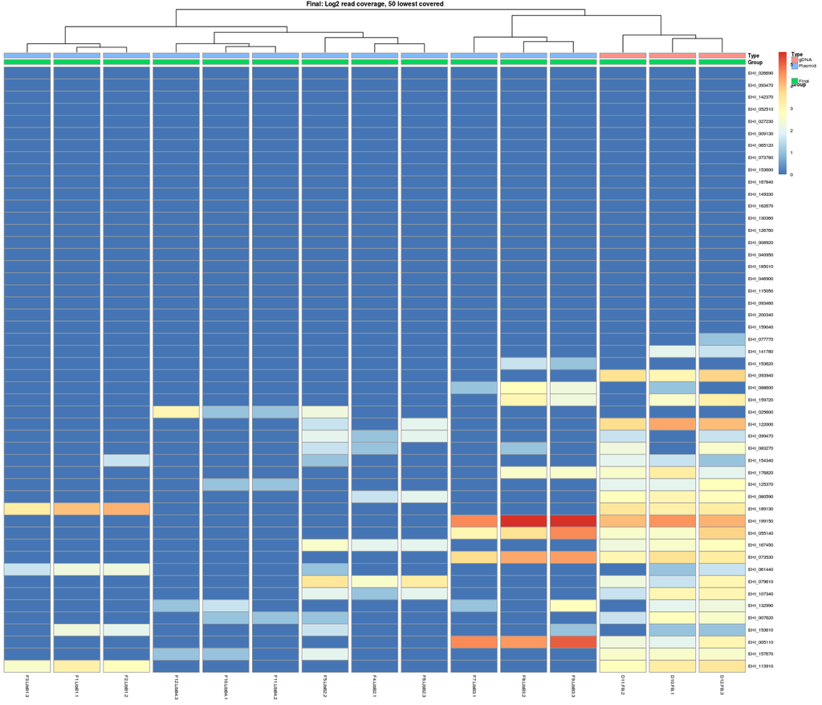

Final: Are any genes not covered in most/all Final samples after pooling?

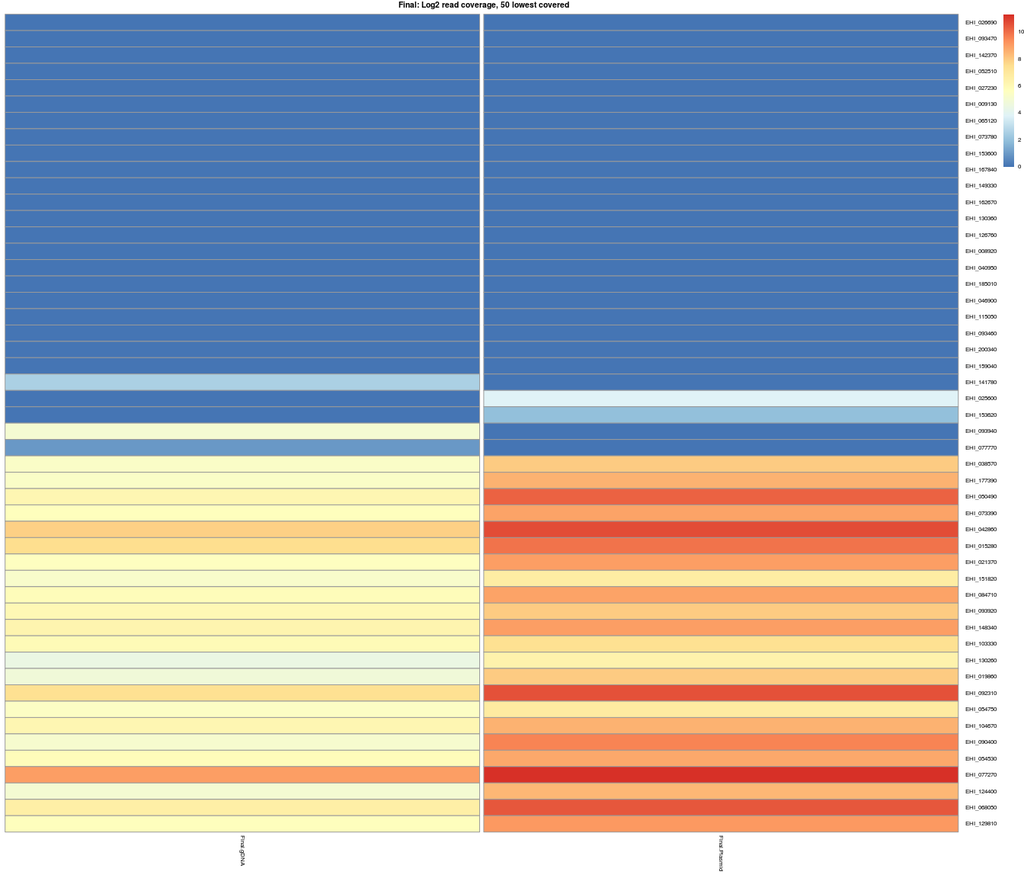

Final: Are any genes not covered in most/all Final samples after pooling?

|  | Final.gDNA | Final.Plasmid |
| --- | --- | --- |
| EHI_026690 | 0 | 0 |
| EHI_093470 | 0 | 0 |
| EHI_142370 | 0 | 0 |
| EHI_052510 | 0 | 0 |
| EHI_027230 | 0 | 0 |
| EHI_009130 | 0 | 0 |
| EHI_065120 | 0 | 0 |
| EHI_073780 | 0 | 0 |
| EHI_153600 | 0 | 0 |
| EHI_167840 | 0 | 0 |
| EHI_149330 | 0 | 0 |
| EHI_162670 | 0 | 0 |
| EHI_130360 | 0 | 0 |
| EHI_126760 | 0 | 0 |
| EHI_008920 | 0 | 0 |
| EHI_040950 | 0 | 0 |
| EHI_185010 | 0 | 0 |
| EHI_046900 | 0 | 0 |
| EHI_115050 | 0 | 0 |
| EHI_093460 | 0 | 0 |
| EHI_200340 | 0 | 0 |
| EHI_159040 | 0 | 0 |
| EHI_141780 | 5 | 0 |
| EHI_025600 | 0 | 13 |
| EHI_153620 | 0 | 3 |
| EHI_093940 | 31 | 0 |
| EHI_077770 | 1 | 0 |
| EHI_038570 | 40 | 245 |
| EHI_177390 | 41 | 379 |
| EHI_050490 | 70 | 1225 |
| EHI_073390 | 52 | 482 |
| EHI_042860 | 224 | 1613 |
| EHI_015280 | 187 | 945 |
| EHI_021370 | 47 | 492 |
| EHI_151820 | 38 | 102 |
| EHI_084710 | 55 | 469 |
| EHI_093920 | 66 | 246 |
| EHI_148340 | 78 | 512 |
| EHI_103330 | 62 | 163 |
| EHI_130260 | 21 | 81 |
| EHI_019860 | 28 | 260 |
| EHI_092310 | 173 | 1578 |
| EHI_054750 | 44 | 115 |
| EHI_104670 | 72 | 366 |
| EHI_090400 | 35 | 781 |
| EHI_054530 | 55 | 443 |
| EHI_077270 | 509 | 2533 |
| EHI_124400 | 32 | 339 |
| EHI_068050 | 98 | 1391 |
| EHI_129810 | 51 | 570 |

## Results for bi-directional read coverage counts:

### Summary statistics for all samples:

|  | Sample | reads | AssignedReads | CoveredGenes | Fragmented.gDNA | Group | Type | Rep | PCR.Cycles |
| --- | --- | --- | --- | --- | --- | --- | --- | --- | --- |
| B1.FA.bam | B1.FA | 320901 | 133554 | 8290 | FA | Pilot | gDNA | 1 | 5 |
| B2.FA.bam | B2.FA | 340395 | 143283 | 8296 | FA | Pilot | gDNA | 2 | 5 |
| B3.FA.bam | B3.FA | 240107 | 107690 | 8249 | FA | Pilot | gDNA | 3 | 5 |
| gLibA.A5.bam | gLibA.A5 | 180884 | 94633 | 339 | FA | Pilot | Plasmid | 1 | 5 |
| gLibA.A6.bam | gLibA.A6 | 264725 | 137146 | 340 | FA | Pilot | Plasmid | 2 | 5 |
| gLibA.A7.bam | gLibA.A7 | 384836 | 190577 | 346 | FA | Pilot | Plasmid | 3 | 5 |
| D10.FB.1.bam | D10.FB.1 | 881505 | 393702 | 8308 | FB | Final | gDNA | 1 | 5 |
| D11.FB.2.bam | D11.FB.2 | 692763 | 309056 | 8304 | FB | Final | gDNA | 2 | 5 |
| D12.FB.3.bam | D12.FB.3 | 976855 | 438327 | 8310 | FB | Final | gDNA | 3 | 5 |
| F1.LibB1.1.bam | F1.LibB1.1 | 972753 | 518536 | 8210 | FB | Final | Plasmid | 1 | 5 |
| F2.LibB1.2.bam | F2.LibB1.2 | 853610 | 449284 | 8213 | FB | Final | Plasmid | 2 | 5 |
| F3.LibB1.3.bam | F3.LibB1.3 | 976763 | 514811 | 8216 | FB | Final | Plasmid | 3 | 5 |
| F4.LibB2.1.bam | F4.LibB2.1 | 950822 | 526525 | 8275 | FB | Final | Plasmid | 1 | 5 |
| F5.LibB2.2.bam | F5.LibB2.2 | 1123212 | 617794 | 8280 | FB | Final | Plasmid | 2 | 5 |
| F6.LibB2.3.bam | F6.LibB2.3 | 1147730 | 627129 | 8276 | FB | Final | Plasmid | 3 | 5 |
| F7.LibB3.1.bam | F7.LibB3.1 | 992325 | 550862 | 8269 | FB | Final | Plasmid | 1 | 5 |
| F8.LibB3.2.bam | F8.LibB3.2 | 1828332 | 1014373 | 8292 | FB | Final | Plasmid | 2 | 5 |
| F9.LibB3.3.bam | F9.LibB3.3 | 1514682 | 834700 | 8287 | FB | Final | Plasmid | 3 | 5 |
| F10.LibB4.1.bam | F10.LibB4.1 | 1524301 | 632640 | 7721 | FB | Final | Plasmid | 1 | 5 |
| F11.LibB4.2.bam | F11.LibB4.2 | 1343977 | 570696 | 7698 | FB | Final | Plasmid | 2 | 5 |
| F12.LibB4.3.bam | F12.LibB4.3 | 2165943 | 924037 | 7814 | FB | Final | Plasmid | 3 | 5 |

### How does gene coverage correspond to sequencing depth?

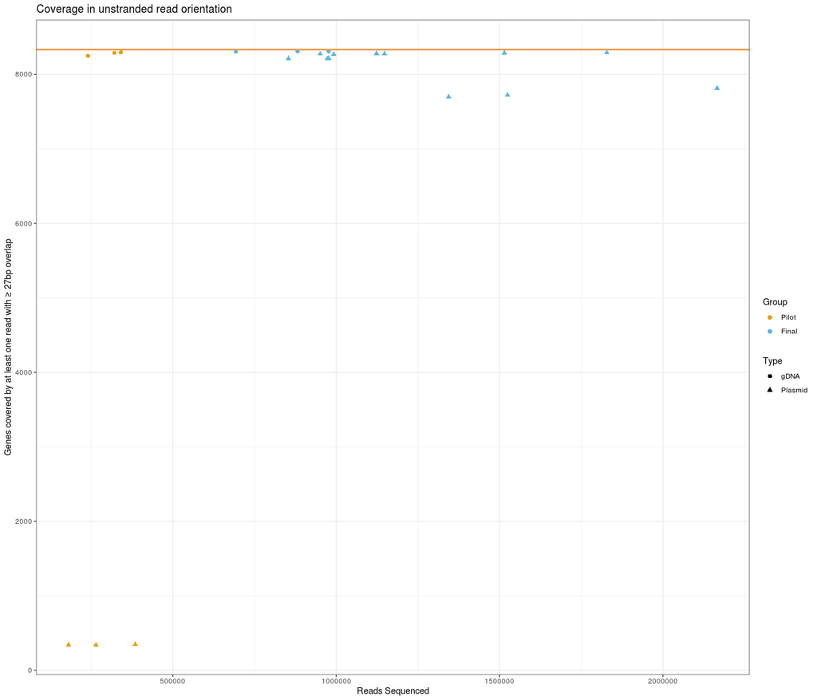

What is the distribution of number of reads mapped per gene?

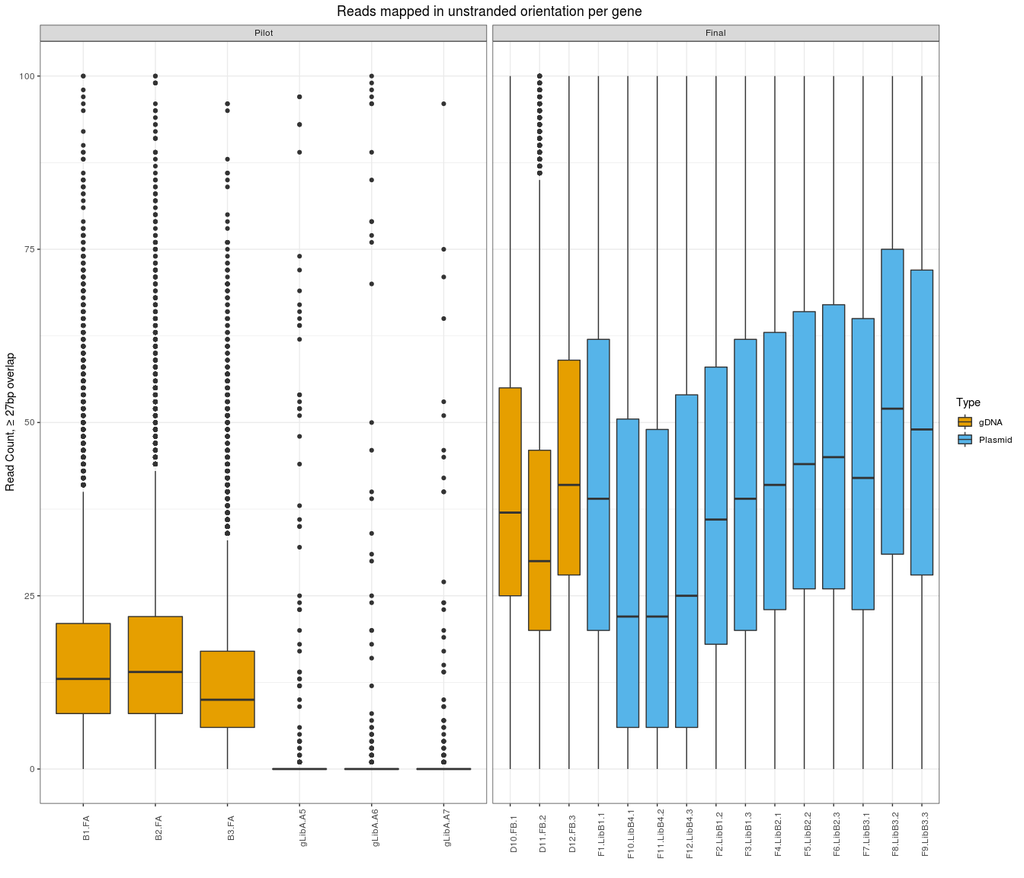

What is read coverage like across all genes, and do samples cluster by prep?

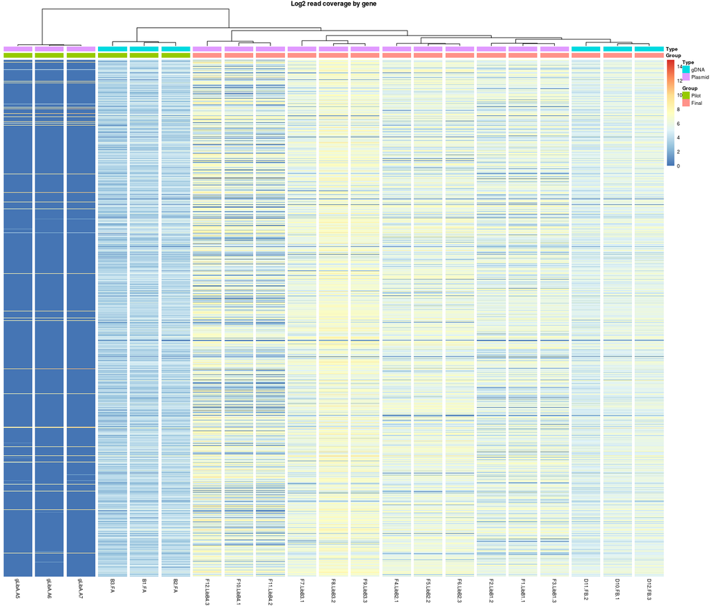

What is read coverage like across all genes for Final samples only? Do samples cluster by prep?

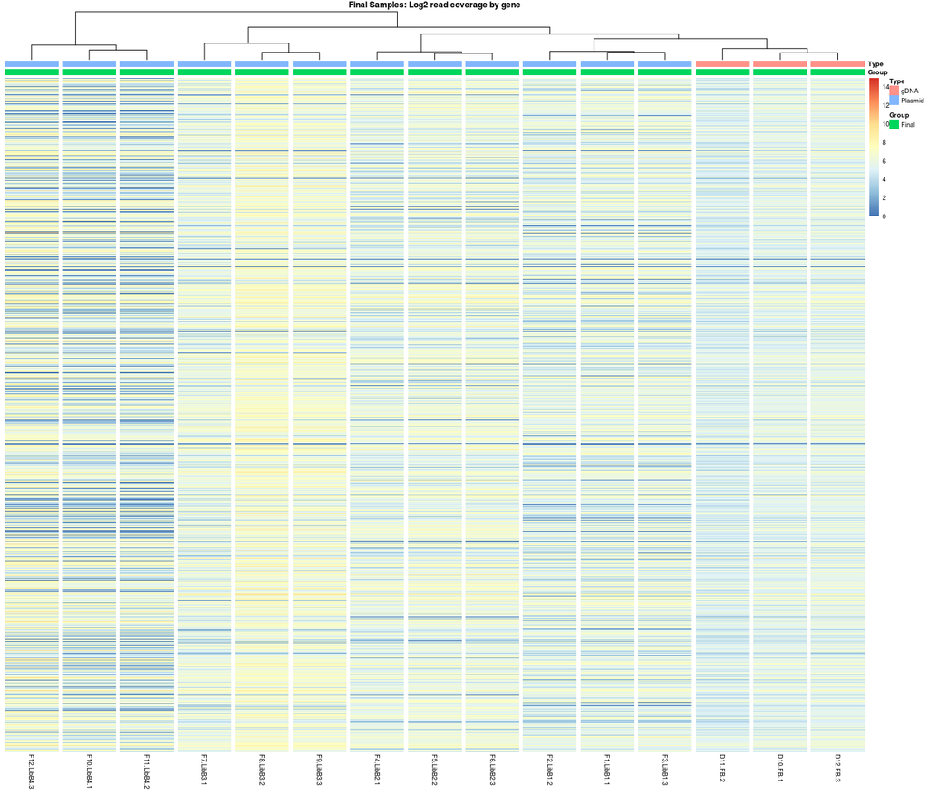

Are any genes not covered in most/all samples?

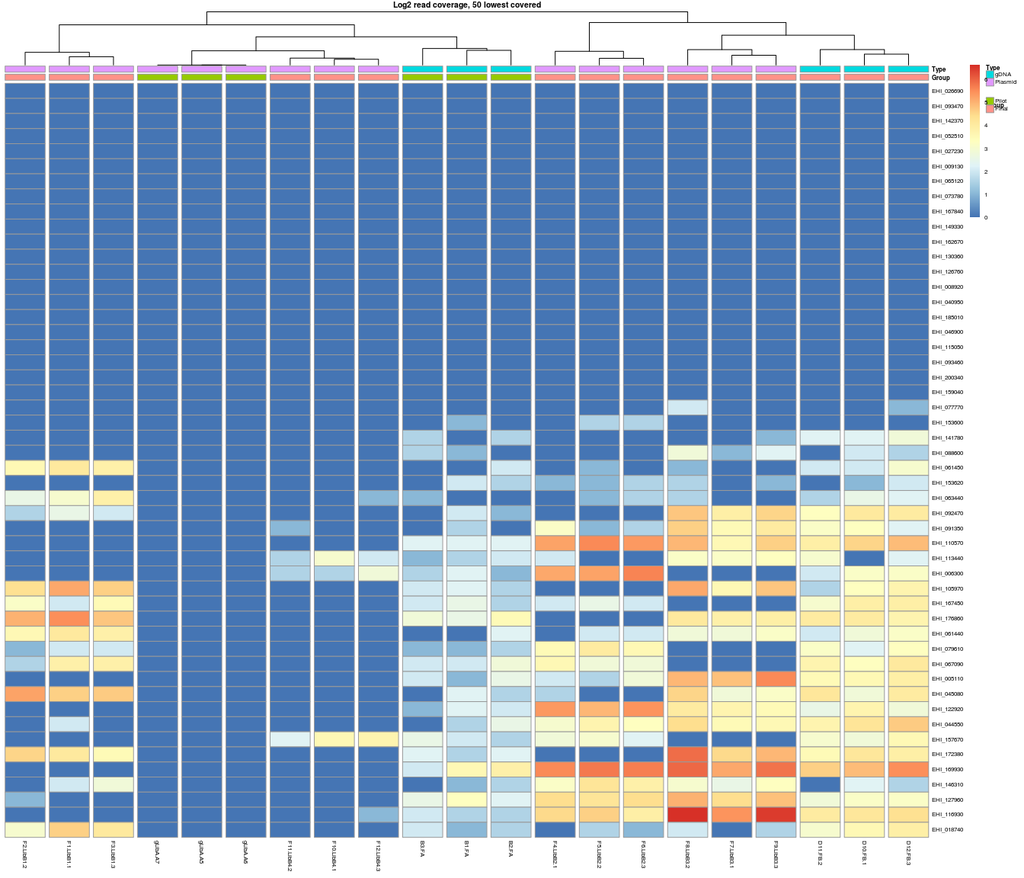

Are any genes not covered in samples from the Final group?

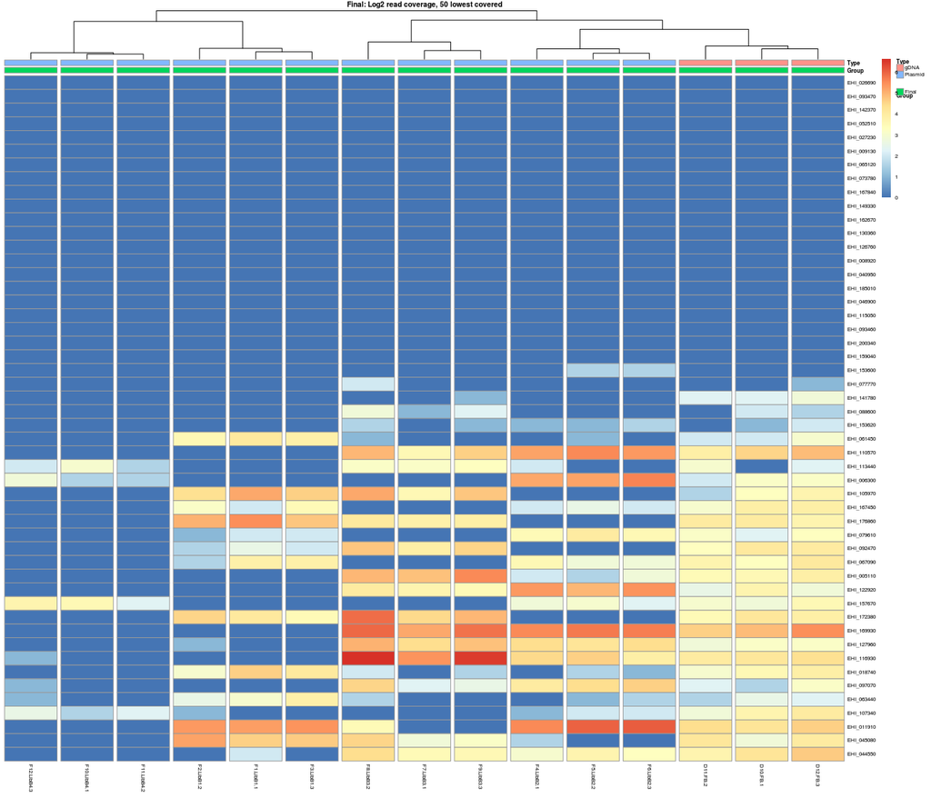

Final: Are any genes not covered in most/all Final samples after pooling?

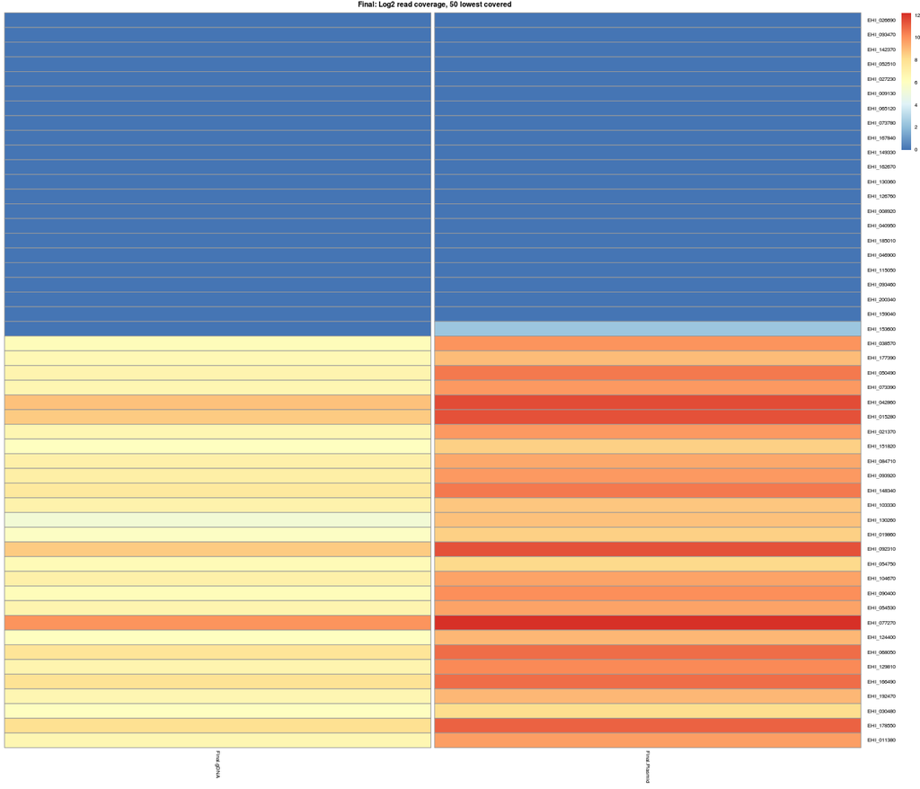

Final: Are any genes not covered in most/all Final samples after pooling?

|  | Final.gDNA | Final.Plasmid |
| --- | --- | --- |
| EHI_026690 | 0 | 0 |
| EHI_093470 | 0 | 0 |
| EHI_142370 | 0 | 0 |
| EHI_052510 | 0 | 0 |
| EHI_027230 | 0 | 0 |
| EHI_009130 | 0 | 0 |
| EHI_065120 | 0 | 0 |
| EHI_073780 | 0 | 0 |
| EHI_167840 | 0 | 0 |
| EHI_149330 | 0 | 0 |
| EHI_162670 | 0 | 0 |
| EHI_130360 | 0 | 0 |
| EHI_126760 | 0 | 0 |
| EHI_008920 | 0 | 0 |
| EHI_040950 | 0 | 0 |
| EHI_185010 | 0 | 0 |
| EHI_046900 | 0 | 0 |
| EHI_115050 | 0 | 0 |
| EHI_093460 | 0 | 0 |
| EHI_200340 | 0 | 0 |
| EHI_159040 | 0 | 0 |
| EHI_153600 | 0 | 4 |
| EHI_038570 | 78 | 954 |
| EHI_177390 | 93 | 513 |
| EHI_050490 | 113 | 1495 |
| EHI_073390 | 101 | 908 |
| EHI_042860 | 455 | 3086 |
| EHI_015280 | 378 | 2624 |
| EHI_021370 | 96 | 889 |
| EHI_151820 | 66 | 368 |
| EHI_084710 | 133 | 727 |
| EHI_093920 | 146 | 927 |
| EHI_148340 | 178 | 1525 |
| EHI_103330 | 123 | 423 |
| EHI_130260 | 40 | 466 |
| EHI_019860 | 58 | 350 |
| EHI_092310 | 378 | 2648 |
| EHI_054750 | 84 | 309 |
| EHI_104670 | 133 | 788 |
| EHI_090400 | 80 | 1099 |
| EHI_054530 | 111 | 770 |
| EHI_077270 | 1027 | 4726 |
| EHI_124400 | 67 | 539 |
| EHI_068050 | 216 | 1857 |
| EHI_129810 | 109 | 1175 |
| EHI_166490 | 239 | 1756 |
| EHI_192470 | 99 | 546 |
| EHI_030480 | 65 | 272 |
| EHI_178550 | 252 | 2184 |
| EHI_011380 | 100 | 820 |

## R session info and packages

**R version 3.6.1 (2019-07-05)**

**Platform:** x86_64-pc-linux-gnu (64-bit)

**locale:** *LC_CTYPE=en_US*, *LC_NUMERIC=C*, *LC_TIME=en_US*, *LC_COLLATE=en_US*, *LC_MONETARY=en_US*, *LC_MESSAGES=en_US*, *LC_PAPER=en_US*, *LC_NAME=C*, *LC_ADDRESS=C*, *LC_TELEPHONE=C*, *LC_MEASUREMENT=en_US* and *LC_IDENTIFICATION=C*

**attached base packages:**

- stats4
- parallel
- stats
- graphics
- grDevices
- utils
- datasets
- methods
- base

**other attached packages:**

- pander(v.0.6.3)
- pheatmap(v.1.0.12)
- ggplot2(v.3.3.0)
- readr(v.1.3.1)
- Rsubread(v.2.0.1)
- Biostrings(v.2.54.0)
- XVector(v.0.26.0)
- IRanges(v.2.20.2)
- S4Vectors(v.0.24.2)
- BiocGenerics(v.0.32.0)
- kableExtra(v.1.1.0)

**loaded via a namespace (and not attached):**

- Rcpp(v.1.0.4.6)
- highr(v.0.8)
- RColorBrewer(v.1.1-2)
- pillar(v.1.4.3)
- compiler(v.3.6.1)
- zlibbioc(v.1.32.0)
- tools(v.3.6.1)
- digest(v.0.6.25)
- gtable(v.0.3.0)
- evaluate(v.0.14)
- lifecycle(v.0.2.0)
- tibble(v.3.0.1)
- viridisLite(v.0.3.0)
- pkgconfig(v.2.0.3)
- rlang(v.0.4.5)
- rstudioapi(v.0.11)
- yaml(v.2.2.1)
- xfun(v.0.13)
- withr(v.2.1.2)
- dplyr(v.0.8.5)
- httr(v.1.4.1)
- stringr(v.1.4.0)
- knitr(v.1.28)
- xml2(v.1.2.5)
- vctrs(v.0.2.4)
- hms(v.0.5.3)
- tidyselect(v.1.0.0)
- grid(v.3.6.1)
- webshot(v.0.5.2)
- glue(v.1.3.2)
- R6(v.2.4.1)
- rmarkdown(v.2.1)
- farver(v.2.0.3)
- purrr(v.0.3.4)
- magrittr(v.1.5)
- scales(v.1.1.0)
- ellipsis(v.0.3.0)
- htmltools(v.0.4.0)
- assertthat(v.0.2.1)
- rvest(v.0.3.5)
- colorspace(v.1.4-1)
- labeling(v.0.3)
- stringi(v.1.4.5)
- munsell(v.0.5.0)
- crayon(v.1.3.4)